# Git, Github e o RStudio

[figure not shown]

- Para que serve
  - Cloud, Versionamento, Copilot, Pages e principalmente **ORGANIZAÇÃO**

# 1 Git e Github

[figure not shown]

Quando você inicia um projeto Git no seu computador, todo o histórico do projeto é armazenado localmente em um repositório. A vantagem do Git é a capacidade de colaborar com outros e armazenar o repositório em outro lugar. GitHub é um site comercial que permite armazenar repositórios publicamente de graça, com opções pagas para privacidade, além de contas educacionais gratuitas com e-mail .edu. Outros sites, como BitBucket, oferecem serviços semelhantes. Esses sites proporcionam interfaces amigáveis para operações comuns, além de recursos úteis como rastreadores de problemas e wikis.

# 2 Versionamento

- Versionamento Local

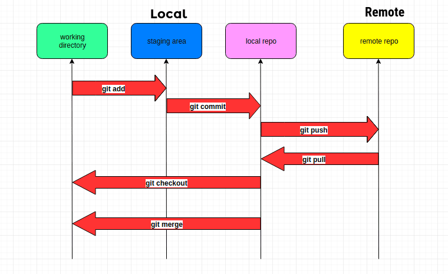

- Versionamento nas Branchs

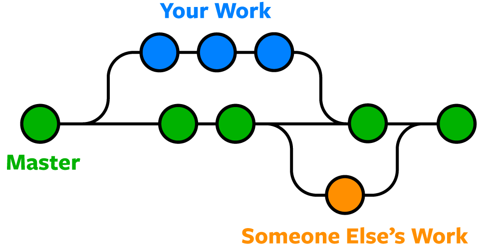

0. Configuração Inicial: **Comando: git config –global user.name “Seu Nome” e git config –global user.email “seuemail@example.com”** Descrição: Configura o nome de usuário e o e-mail que serão associados aos commits.
1. Iniciar um Repositório: **Comando: git init**. Descrição: Inicializa um novo repositório Git em um diretório, criando a estrutura necessária para começar a versionar arquivos.
2. Adicionar Arquivos: **Comando: git add** . Descrição: Adiciona arquivos ao índice (staging area), preparando-os para serem incluídos no próximo commit.
3. Fazer Commit: **Comando: git commit -m “mensagem do commit”**. Descrição: Salva as mudanças adicionadas no índice no repositório, criando um novo ponto no histórico do projeto com uma mensagem descritiva.
4. Verificar Status: **Comando: git status**. Descrição: Mostra o estado atual do repositório, incluindo arquivos modificados, novos arquivos não rastreados e arquivos preparados para commit.
5. Visualizar Histórico: **Comando: git log**. Descrição: Exibe o histórico de commits do repositório, permitindo ver mensagens de commit, autores e datas.
6. Comparar Alterações: **Comando: git diff**. Descrição: Compara mudanças entre a área de trabalho, o índice e os commits anteriores, mostrando diferenças entre versões de arquivos.
7. Reverter Alterações: **Comando: git checkout –** . Descrição: Desfaz modificações locais em um arquivo, retornando à última versão commitada ou indexada.
8. Excluir Arquivos do Índice: **Comando: git rm** . Descrição: Remove um arquivo do índice e do diretório de trabalho, preparando-o para ser excluído no próximo commit.
9. Criar e Alternar Ramificações: **Comando: git branch e git checkout** Descrição: git branch lista e cria novas ramificações, enquanto git checkout alterna entre ramificações existentes.
10. Mesclar Ramificações: **Comando: git merge** Descrição: Integra mudanças de uma ramificação específica na ramificação atual, combinando diferentes linhas de desenvolvimento.
11. Visualizar Ramificações: **Comando: git branch -v** Descrição: Lista todas as ramificações com a última mensagem de commit para cada uma.
12. Stash Alterações: **Comando: git stash** Descrição: Salva temporariamente mudanças não commitadas para poder trabalhar em outra coisa, restaurando-as mais tarde com git stash apply.

Estas etapas abrangem os conceitos e comandos básicos do versionamento local usando Git, permitindo gerenciar e rastrear mudanças em projetos de forma eficiente

# 3 Copilot

[figure not shown]

GitHub Copilot é uma ferramenta de inteligência artificial desenvolvida pela GitHub em parceria com a OpenAI. Funciona como um assistente de codificação que ajuda a escrever código de maneira mais rápida e eficiente.

- Principais Funcionalidades
- Autocompletar Código: Sugere linhas ou blocos inteiros de código enquanto você digita, baseado no contexto do seu projeto.
- Suporte Multilíngue: Oferece suporte para diversas linguagens de programação, incluindo Python, JavaScript, TypeScript, Ruby, Go, entre outras.
- Geração de Código a Partir de Comentários: Pode transformar descrições em linguagem natural (comentários) em código funcional.
- Refatoração e Sugestões: Propõe melhorias e refatorações para o código existente.

# 4 Git e Rstudio

O git;github e o Rstudi já oferecem uma maneira de desenvolvimento de cófigo integrada. Para isso, voce deve inicializar o seu diretório via opção de versionamento de controle

1. Acesse o Github: https://github.com/, e crie um novo repositório: https://github.com/new

[figure not shown]

2. Copie o link do repositório
3. Criu um repositório no Rstudi0

[figure not shown]

[figure not shown]

[figure not shown]

Se estiver correto, seu diretório local no RStudio deverá estará linkado com o diretório online do GitHub.

Voce pode verificar isso na aba de **Environment / History / Connections / Tutorial** que deverá possui uma nova aba chamada Git

[figure not shown]

# 5 Github Pages

O github disponibiliza uma forma simples, rápida e grátis de criação de website, chamado de Github Pages

Você pode armazenar seu portfólio, por exemplo https: https://gustavo039.github.io

Criar site para disciplinas, https://gustavo039.github.io/mat_ufjf.html

Ou divulgar outra área de estudo seu, https://gustavo039.github.io/fableCount/index.html

Para criação de sites, o RStudio juntamente com o Quarto podem ser seu braço direito

A principais referências podem ser encontradas em: https://quarto.org/docs/websites/ e https://quarto.org/docs/publishing/github-pages.html

# 6 Considerações Finais

- A organização é a chave para estudos consistentes
- O mundo de tecnologia sempre está mudando, não se prendam a nada…
- IA não é apenas Chat GPT…

# 7 Referências

- HILL, Alison. Rstudio4edu - A Handbook for Teaching and Learning with R and RStudio [recurso eletrônico]. 1. ed. Disponível em: https://rstudio4edu.github.io/rstudio4edu-book/.
- BRYAN, Jennifer. Happy Git and GitHub for the useR [recurso eletrônico].Disponível em: https://happygitwithr.com/
- Quarto https://quarto.org/.